# Problema 1

```
Test error = 1.3840114198838984 Learning rate = 0.001
```

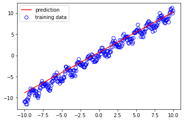

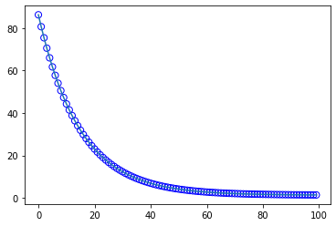

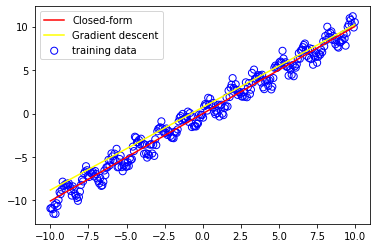

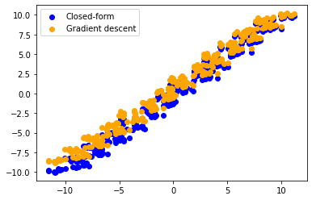

```
Test error = 0.7737061917922952 Learning rate = 0.01
```

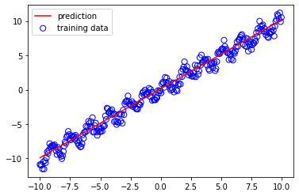

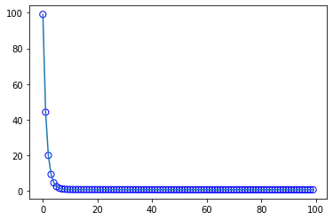

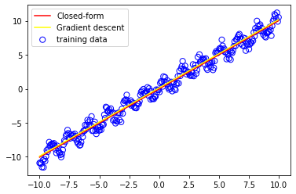

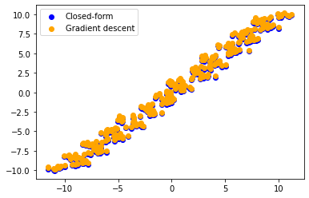

```
Test error = 1.7245093173607892e+74 Learning rate = 0.1
```

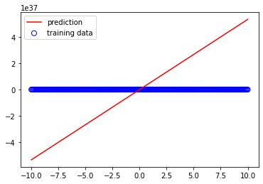

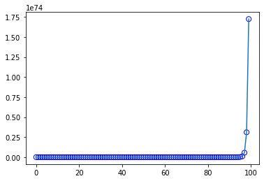

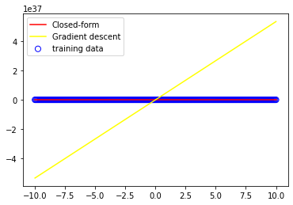

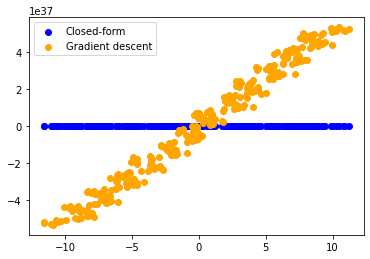

```
Test error = 5.59228864572409e+236 Learning rate = 0.5
```

[13 more figures not shown]

```python
# Complex dataset
n_samples = 300
X_full = np.linspace(-10, 10, n_samples) # coordinates
noise_sample = np.random.normal(0, 0.5, n_samples)
t_full = X_full + np.sin(4*X_full) + noise_sample
X_full = [[xx] for xx in X_full]
X_full = np.asarray(X_full)

errors = {}


model = LinearRegression()
X_full_feat = extract_polynomial_features(X_full, 1)

model.fit(X_full_feat, t_full)

y_full = np.zeros(X_full.size)
y_full = model.predict(X_full_feat, False)


plot_x = [i for i in range(100)]

W, error = train_gradient_descent(X_full, t_full, 10**(-3), 100)
errors[10**(-3)] = error

X_hat = np.concatenate([X_full, np.ones((X_full.shape[0], 1))], axis=1)
Y = X_hat @ W
print("Test error =", error[len(error) - 1], "Learning rate =", 10**(-3))
plt.scatter(X_full, t_full, facecolor="none", edgecolor="b", s=50, label="training data")
plt.plot(X_full, Y, color="red", label="prediction")
plt.legend()
plt.show()

plt.plot(plot_x, error)
plt.scatter(plot_x, error, facecolor="none", edgecolor="b", s=50)
plt.show()

plt.scatter(X_full, t_full, facecolor="none", edgecolor="b", s=50, label="training data")
plt.plot(X_full, y_full, color="red", label="Closed-form")
plt.plot(X_full, Y, color="yellow", label="Gradient descent")
plt.legend()
plt.show()

plt.scatter(t_full, y_full, color="blue", label="Closed-form")
plt.scatter(t_full, Y, color="orange", label="Gradient descent")
plt.legend()
plt.show()


W, error = train_gradient_descent(X_full, t_full, 10**(-2), 100)
errors[10**(-2)] = error
X_hat = np.concatenate([X_full, np.ones((X_full.shape[0], 1))], axis=1)
Y = X_hat @ W
print("Test error =", error[len(error) - 1], "Learning rate =",10**(-2))
plt.scatter(X_full, t_full, facecolor="none", edgecolor="b", s=50, label="training data")
plt.plot(X_full, Y, color="red", label="prediction")
plt.legend()
plt.show()

plt.plot(plot_x, error)
plt.scatter(plot_x, error, facecolor="none", edgecolor="b", s=50)
plt.show()

plt.scatter(X_full, t_full, facecolor="none", edgecolor="b", s=50, label="training data")
plt.plot(X_full, y_full, color="red", label="Closed-form")
plt.plot(X_full, Y, color="yellow", label="Gradient descent")
plt.legend()
plt.show()

plt.scatter(t_full, y_full, color="blue", label="Closed-form")
plt.scatter(t_full, Y, color="orange", label="Gradient descent")
plt.legend()
plt.show()

W, error = train_gradient_descent(X_full, t_full, 10**(-1), 100)
errors[10**(-1)] = error
X_hat = np.concatenate([X_full, np.ones((X_full.shape[0], 1))], axis=1)
Y = X_hat @ W
print("Test error =", error[len(error) - 1], "Learning rate =", 10**(-1))
plt.scatter(X_full, t_full, facecolor="none", edgecolor="b", s=50, label="training data")
plt.plot(X_full, Y, color="red", label="prediction")
plt.legend()
plt.show()

plt.plot(plot_x, error)
plt.scatter(plot_x, error, facecolor="none", edgecolor="b", s=50)
plt.show()

plt.scatter(X_full, t_full, facecolor="none", edgecolor="b", s=50, label="training data")
plt.plot(X_full, y_full, color="red", label="Closed-form")
plt.plot(X_full, Y, color="yellow", label="Gradient descent")
plt.legend()
plt.show()

plt.scatter(t_full, y_full, color="blue", label="Closed-form")
plt.scatter(t_full, Y, color="orange", label="Gradient descent")
plt.legend()
plt.show()

W, error = train_gradient_descent(X_full, t_full, 1/2, 100)
errors[1/2] = error
X_hat = np.concatenate([X_full, np.ones((X_full.shape[0], 1))], axis=1)
Y = X_hat @ W
print("Test error =", error[len(error) - 1], "Learning rate =", 1/2)
plt.scatter(X_full, t_full, facecolor="none", edgecolor="b", s=50, label="training data")
plt.plot(X_full, Y, color="red", label="prediction")
plt.legend()
plt.show()

plt.plot(plot_x, error)
plt.scatter(plot_x, error, facecolor="none", edgecolor="b", s=50)
plt.show()

plt.scatter(X_full, t_full, facecolor="none", edgecolor="b", s=50, label="training data")
plt.plot(X_full, y_full, color="red", label="Closed-form")
plt.plot(X_full, Y, color="yellow", label="Gradient descent")
plt.legend()
plt.show()

plt.scatter(t_full, y_full, color="blue", label="Closed-form")
plt.scatter(t_full, Y, color="orange", label="Gradient descent")
plt.legend()
plt.show()

W, error = train_gradient_descent(X_full, t_full, 1/5, 100)
errors[1/5] = error
X_hat = np.concatenate([X_full, np.ones((X_full.shape[0], 1))], axis=1)
Y = X_hat @ W
print("Test error =", error[len(error) - 1], "Learning rate =", 1/5)
plt.scatter(X_full, t_full, facecolor="none", edgecolor="b", s=50, label="training data")
plt.plot(X_full, Y, color="red", label="prediction")
plt.legend()
plt.show()

plt.plot(plot_x, error)
plt.scatter(plot_x, error, facecolor="none", edgecolor="b", s=50)
plt.show()

plt.scatter(X_full, t_full, facecolor="none", edgecolor="b", s=50, label="training data")
plt.plot(X_full, y_full, color="red", label="Closed-form")
plt.plot(X_full, Y, color="yellow", label="Gradient descent")
plt.legend()
plt.show()

plt.scatter(t_full, y_full, color="blue", label="Closed-form")
plt.scatter(t_full, Y, color="orange", label="Gradient descent")
plt.legend()
plt.show()


lr_newton_raphson = 1/max(np.linalg.eigh(np.transpose(X_full) @ X_full))
W, error = train_gradient_descent(X_full, t_full, lr_newton_raphson[0], 100)
errors["NR"] = error
X_hat = np.concatenate([X_full, np.ones((X_full.shape[0], 1))], axis=1)
Y = X_hat @ W
print("Test error =", error[len(error) - 1], "Newton-Raphson Learning rate =", lr_newton_raphson[0])
plt.scatter(X_full, t_full, facecolor="none", edgecolor="b", s=50, label="training data")
plt.plot(X_full, Y, color="red", label="prediction")
plt.legend()
plt.show()

plt.plot(plot_x, error)
plt.scatter(plot_x, error, facecolor="none", edgecolor="b", s=50)
plt.show()

plt.scatter(X_full, t_full, facecolor="none", edgecolor="b", s=50, label="training data")
plt.plot(X_full, y_full, color="red", label="Closed-form")
plt.plot(X_full, Y, color="yellow", label="Gradient descent")
plt.legend()
plt.show()

plt.scatter(t_full, y_full, color="blue", label="Closed-form")
plt.scatter(t_full, Y, color="orange", label="Gradient descent")
plt.legend()
plt.show()

plt.plot(plot_x, errors[10**(-3)], '-o', label="1.00e-03")
plt.plot(plot_x, errors[10**(-2)], '-o', label="1.00e-02")
plt.plot(plot_x, errors[10**(-1)], '-o', label="1.00e-01")
plt.plot(plot_x, errors[1/2], '-o', label="2.00e-01")
plt.plot(plot_x, errors[1/5], '-o', label="5.00e-01")
plt.plot(plot_x, errors["NR"], '-o', label="Newton-Raphson")
plt.ylim([0, 100])
plt.legend()
plt.show()
```

# 1.3 Mini-Batch Gradient Descent

```python
def train_mini_batch_gradient_descent(X, T, batch_size=20, lr=.01, epochs_no=100):
  (N_total, D) = X.shape
  W = np.random.randn((D+1))
  error = []
  all_errors = []
  for i in range(epochs_no):
    indices = np.random.permutation(N_total)
    x_rand = X[indices]
    t_rand = T[indices]
    epoch_errors = []
    for j in range(0, len(X), batch_size):
      X_batch = x_rand[j:j+batch_size]
      T_batch = t_rand[j:j+batch_size]
      N = X_batch.shape[0]
      X_batch_hat = np.concatenate([X_batch, np.ones((N, 1))], axis=1)
      Y_batch = X_batch_hat @ W
      W = W - lr * np.transpose(X_batch_hat)@(Y_batch - T_batch)/batch_size
      epoch_errors.append(mean_squared_error(Y_batch, T_batch))
      all_errors.append(mean_squared_error(Y_batch, T_batch))
    error.append(np.mean(epoch_errors))
  return W, error, all_errors
```

```
Test error = 440.5917683011938 Batch size = 10
```

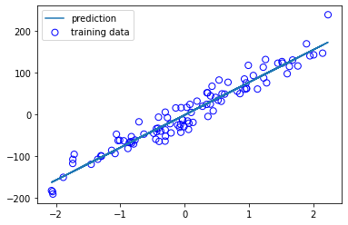

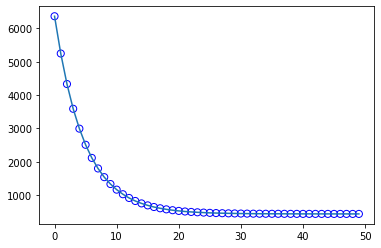

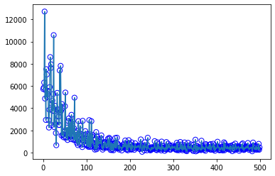

```
Test error = 476.2833572688572 Batch size = 20
```

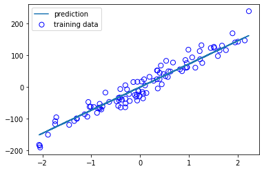

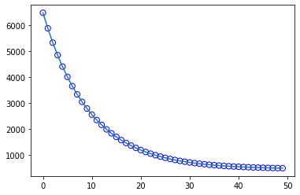

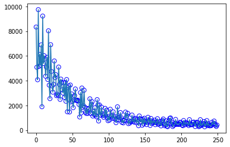

```
Test error = 536.6949043874962 Batch size = 25
```

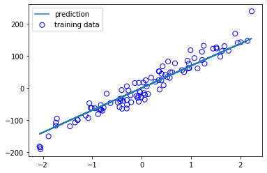

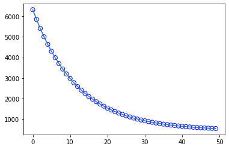

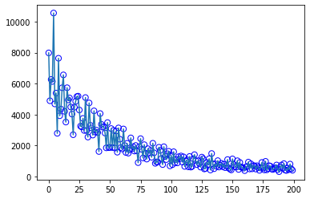

```
2.0
Test error = 1238.7524348154025 Batch size = 50
```

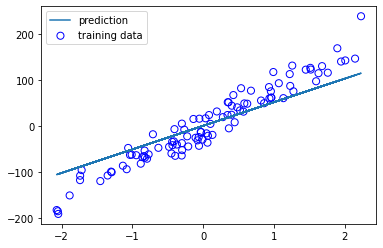

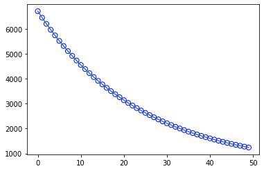

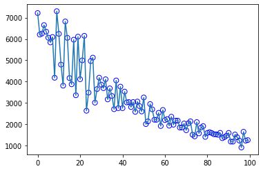

[2 more figures not shown]

```python
n_samples = 100
n_features = 1
noise = 20
X_full, t_full = datasets.make_regression(n_samples=n_samples, n_features=n_features, n_informative=1, noise=noise, random_state=37)

errors = {}
all_erros_dic = {}

epochs = 50

batch_size = 10
W, error, all_errors = train_mini_batch_gradient_descent(X_full, t_full, batch_size, 0.01, epochs)
errors[10] = error
all_erros_dic[10] = all_errors
X_hat = np.concatenate([X_full, np.ones((X_full.shape[0], 1))], axis=1)
Y = X_hat @ W
plot_x = [i for i in range(epochs)]

print("Test error =", error[-1], "Batch size =", batch_size)
plt.scatter(X_full, t_full, facecolor="none", edgecolor="b", s=50, label="training data")
plt.plot(X_full, Y, label="prediction")
plt.legend()
plt.show()

plt.plot(plot_x, error)
plt.scatter(plot_x, error, facecolor="none", edgecolor="b", s=50)
plt.show()

plt.plot([i for i in range(500)], all_errors)
plt.scatter([i for i in range(500)], all_errors, facecolor="none", edgecolor="b", s=50)
plt.show()


batch_size = 20
W, error, all_errors = train_mini_batch_gradient_descent(X_full, t_full, batch_size, 0.01, epochs)
errors[20] = error
all_erros_dic[20] = all_errors
X_hat = np.concatenate([X_full, np.ones((X_full.shape[0], 1))], axis=1)
Y = X_hat @ W

print("Test error =", error[-1], "Batch size =", batch_size)
plt.scatter(X_full, t_full, facecolor="none", edgecolor="b", s=50, label="training data")
plt.plot(X_full, Y, label="prediction")
plt.legend()
plt.show()

plt.plot(plot_x, error)
plt.scatter(plot_x, error, facecolor="none", edgecolor="b", s=50)
plt.show()

plt.plot([i for i in range(250)], all_errors)
plt.scatter([i for i in range(250)], all_errors, facecolor="none", edgecolor="b", s=50)
plt.show()


batch_size = 25
W, error, all_errors = train_mini_batch_gradient_descent(X_full, t_full, batch_size, 0.01, epochs)
errors[25] = error
all_erros_dic[25] = all_errors
X_hat = np.concatenate([X_full, np.ones((X_full.shape[0], 1))], axis=1)
Y = X_hat @ W

print("Test error =", error[-1], "Batch size =", batch_size)
plt.scatter(X_full, t_full, facecolor="none", edgecolor="b", s=50, label="training data")
plt.plot(X_full, Y, label="prediction")
plt.legend()
plt.show()

plt.plot(plot_x, error)
plt.scatter(plot_x, error, facecolor="none", edgecolor="b", s=50)
plt.show()

plt.plot([i for i in range(200)], all_errors)
plt.scatter([i for i in range(200)], all_errors, facecolor="none", edgecolor="b", s=50)
plt.show()


batch_size = 50
W, error, all_errors = train_mini_batch_gradient_descent(X_full, t_full, batch_size, 0.01, epochs)
errors[50] = error
all_erros_dic[50] = all_errors
X_hat = np.concatenate([X_full, np.ones((X_full.shape[0], 1))], axis=1)
Y = X_hat @ W
print(n_samples/batch_size)

print("Test error =", error[-1], "Batch size =", batch_size)
plt.scatter(X_full, t_full, facecolor="none", edgecolor="b", s=50, label="training data")
plt.plot(X_full, Y, label="prediction")
plt.legend()
plt.show()

plt.plot(plot_x, error)
plt.scatter(plot_x, error, facecolor="none", edgecolor="b", s=50)
plt.show()

plt.plot([i for i in range(100)], all_errors)
plt.scatter([i for i in range(100)], all_errors, facecolor="none", edgecolor="b", s=50)
plt.show()


plt.plot(plot_x, errors[10], '-o', label="Batch size=10")
plt.plot(plot_x, errors[20], '-o', label="Batch size=20")
plt.plot(plot_x, errors[25], '-o', label="Batch size=25")
plt.plot(plot_x, errors[50], '-o', label="Batch size=50")

plt.legend()
plt.show()


plt.plot([i for i in range(500)], all_erros_dic[10], '-o', label="Batch size=10")
plt.plot([i for i in range(250)], all_erros_dic[20], '-o', label="Batch size=20")
plt.plot([i for i in range(200)], all_erros_dic[25], '-o', label="Batch size=25")
plt.plot([i for i in range(100)], all_erros_dic[50], '-o', label="Batch size=50")

plt.legend()
plt.show()
```

# 1.4 Stochastic Gradient Descent

```python
def train_stochastic_gradient_descent(X, T, lr=.01, epochs_no=100):
  (N_total, D) = X.shape
  W = np.random.randn((D+1))
  error = []
  all_errors = []
  for i in range(epochs_no):
    indices = np.random.permutation(N_total)
    x_rand = X[indices]
    t_rand = T[indices]
    epoch_errors = []
    for j in range(0, len(X)):
      X_batch = x_rand[j].reshape(1, D)
      T_batch = t_rand[j].reshape(1, 1)
      N = X_batch.shape[0]
      X_batch_hat = np.concatenate([X_batch, np.ones((N, 1))], axis=1)
      Y_batch = X_batch_hat @ W
      W = W - lr * np.transpose(X_batch_hat)@(Y_batch - T_batch)
      epoch_errors.append(mean_squared_error(Y_batch, T_batch))
      all_errors.append(mean_squared_error(Y_batch, T_batch))
    error.append(np.mean(epoch_errors))
  return W, error, all_errors
```

```
Test error = 449.0895714292035 Learning rate = 0.01
```

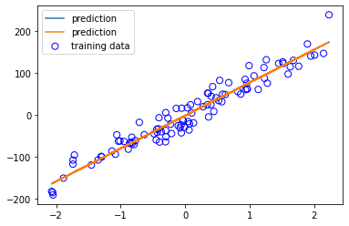

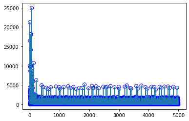

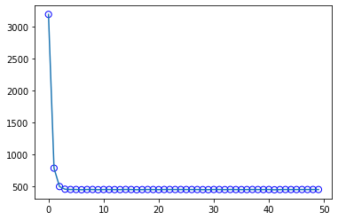

```python
n_samples = 100
n_features = 1
noise = 20
X_full, t_full = datasets.make_regression(n_samples=n_samples, n_features=n_features, n_informative=1, noise=noise, random_state=37)

epochs = 50
plot_x = [i for i in range(5000)]
plot_x_epoch = [i for i in range(epochs)]
W, error, all_errors = train_stochastic_gradient_descent(X_full, t_full, 0.01, epochs)
X_hat = np.concatenate([X_full, np.ones((X_full.shape[0], 1))], axis=1)
Y = X_hat @ W
print("Test error =", error[-1], "Learning rate =", 0.01)
plt.scatter(X_full, t_full, facecolor="none", edgecolor="b", s=50, label="training data")
plt.plot(X_full, Y, label="prediction")
plt.legend()
plt.show()

plt.plot(plot_x, all_errors)
plt.scatter(plot_x, all_errors, facecolor="none", edgecolor="b", s=50)
plt.show()

plt.plot(plot_x_epoch, error)
plt.scatter(plot_x_epoch, error, facecolor="none", edgecolor="b", s=50)
plt.show()
```

# 1.5 Analiza comparativa

Closed-Form:

Mean Squared Error

Train error: 449.6332334520888

Test error: 420.7859565018742

Root Mean Squared Error

Train error: 21.204556902988774

Test error: 20.51306794465114

Gradient descent

Test error = 3240.736442929122 Learning rate = 0.001

Test error = 441.2396847712342 Learning rate = 0.01

Test error = 441.87558256871256 Newton-Raphson Learning rate = 0.009548883827190836

Test error = 439.6417796245061 Learning rate = 0.1

Test error = 439.6417796245061 Learning rate = 0.5

Test error = 439.6417796245061 Learning rate = 0.2

Cu cat learning rate-ul este mai ridicat, solutia converge la o eroare de 439.6417796245061

Mini-Batch Gradient Descent

Test error = 440.58996588381706 Batch size = 10

Test error = 476.32154250021085 Batch size = 20

Test error = 542.5635141363914 Batch size = 25

Test error = 1212.4355800513083 Batch size = 50

Cu cat dimensiunea batch-ului este mai scazuta, eroarea este mai mica. Graficul erororilor este instabil, variaza foarte mult.

Stochastic Gradient Descent

Learning rate = 0.01

Test error = 449.0895714292035 Learning rate = 0.01

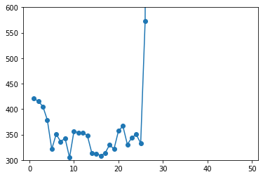

```python
# Simple dataset
n_samples = 100
n_features = 1
noise = 20
X_full, t_full = datasets.make_regression(n_samples=n_samples, n_features=n_features, n_informative=1, noise=noise, random_state=37)
X_train, t_train, X_test, t_test = split_dataset(X_full, t_full)
X_real, t_real = datasets.make_regression(n_samples=n_samples, n_features=n_features, n_informative=1, noise=0., random_state=37)

errors = []
for features in range(1, 50):
  model = LinearRegression()
  X_train_feat = extract_polynomial_features(X_train, features)
  X_test_feat = extract_polynomial_features(X_test, features)

  model.fit(X_train_feat, t_train)
  y_train = model.predict(X_train_feat, False)
  y_test, y_test_std = model.predict(X_test_feat, True)

  errors.append(mean_squared_error(y_test, t_test))


plt.plot([i for i in range(1, 50)], errors, '-o')
plt.ylim([300, 600])
plt.show()
```

# Problema 2

```python
class RidgeRegression(LinearRegression):
    """
    Modelul de regresie liniara, folosind regularizare L2
    w* = argmin |t - X @ w| + alpha * |w|_2^2
    """

    def __init__(self, alpha:float=1.):
        super(RidgeRegression, self).__init__()
        self.alpha = alpha


    def fit(self, X:np.ndarray, t:np.ndarray):
        """
        Antrenarea modelului in sensul celor mai mici patrate (least squares fitting), tinand cont si de regularizare
        Parameterii
        ----------
         X : (N, D) np.ndarray
            variabilele de intrare
        t : (N,) np.ndarray
            variabilele tinta (target / ground truth)
        """
        # TODO codul vostru aici: calculati vectorul de ponderi w, conform formulei de la punctul 5
        N, D = X.shape
        self.w = np.zeros(D)
        X_t = np.transpose(X)
        self.w = np.linalg.inv(X_t @ X + self.alpha * np.identity(D)) @ X_t @ t

        # end

        self.var = np.mean(np.square(X @ self.w - t))
```

```
Mean Squared Error
Train error: 449.6882648528307
Test  error: 416.17536354083757
Root Mean Squared Error
Train error: 21.20585449475759
Test  error: 20.400376553898155
```

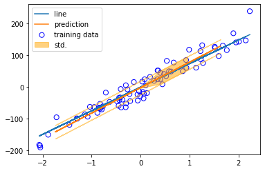

```
{0.0: 462.05161769664704, 0.05: 461.05041772765185, 0.1: 461.4389757261732, 0.15000000000000002: 461.0864226512688, 0.2: 458.9494514885367, 0.25: 461.69864932896905, 0.30000000000000004: 461.4972369179754, 0.35000000000000003: 461.22967854791375, 0.4: 461.66031117786, 0.45: 461.9292920675928, 0.5: 4…
dict_values([462.05161769664704, 461.05041772765185, 461.4389757261732, 461.0864226512688, 458.9494514885367, 461.69864932896905, 461.4972369179754, 461.22967854791375, 461.66031117786, 461.9292920675928, 461.8461551942566, 462.91792968306504, 461.4934381680313, 462.5431738261937, 461.39027292289063…
0.2   458.9494514885367
```

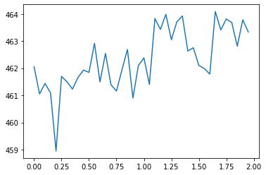

```
{0.0: 461.5302642016358, 0.05: 462.1502030815141, 0.1: 460.8714800300825, 0.15000000000000002: 461.80744829640906, 0.2: 461.3693438401126, 0.25: 460.9235640285649, 0.30000000000000004: 462.6039060043566, 0.35000000000000003: 461.174888247585, 0.4: 461.4053257304545, 0.45: 462.3389723599147, 0.5: 462…
dict_values([461.5302642016358, 462.1502030815141, 460.8714800300825, 461.80744829640906, 461.3693438401126, 460.9235640285649, 462.6039060043566, 461.174888247585, 461.4053257304545, 462.3389723599147, 462.0705421182449, 460.3411919187527, 460.4780366317789, 461.5188452466509, 461.96060619897025, 4…
0.55   460.3411919187527
```

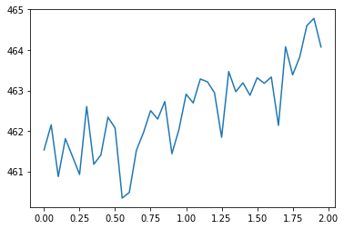

```
{0.0: 461.11052058842523, 0.05: 461.87913417194017, 0.1: 461.1713460898565, 0.15000000000000002: 461.7042250502244, 0.2: 461.6490386437785, 0.25: 461.4590395067043, 0.30000000000000004: 461.6691595886798, 0.35000000000000003: 460.4863310829169, 0.4: 463.5562114695469, 0.45: 462.3692661145655, 0.5: 4…
dict_values([461.11052058842523, 461.87913417194017, 461.1713460898565, 461.7042250502244, 461.6490386437785, 461.4590395067043, 461.6691595886798, 460.4863310829169, 463.5562114695469, 462.3692661145655, 463.2253304338527, 462.3588330067248, 459.613396943049, 461.3731881040286, 462.0961682419108, 4…
0.6000000000000001   459.613396943049
```

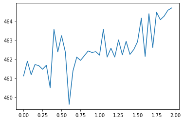

```
{0.0: 460.95736335291093, 0.05: 461.65656646633545, 0.1: 459.9640250826487, 0.15000000000000002: 462.1594409024774, 0.2: 461.35655600495966, 0.25: 460.8664340913885, 0.30000000000000004: 462.10007263938326, 0.35000000000000003: 462.61698149354515, 0.4: 460.8439880784388, 0.45: 460.90327391235206, 0.…
dict_values([460.95736335291093, 461.65656646633545, 459.9640250826487, 462.1594409024774, 461.35655600495966, 460.8664340913885, 462.10007263938326, 462.61698149354515, 460.8439880784388, 460.90327391235206, 462.1544571245177, 460.94334619680455, 461.18064429692566, 461.4309800770176, 462.371205775…
0.1   459.9640250826487
```

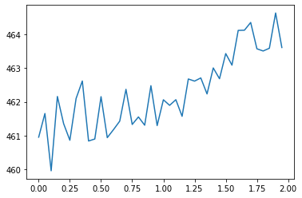

```
{0.0: 462.27552749030485, 0.05: 461.4092974339588, 0.1: 462.1474484287571, 0.15000000000000002: 461.1784186647691, 0.2: 462.2093006576684, 0.25: 463.01282950436297, 0.30000000000000004: 462.42906608968894, 0.35000000000000003: 461.45288793406223, 0.4: 462.75441642385863, 0.45: 462.12728060410194, 0.…
dict_values([462.27552749030485, 461.4092974339588, 462.1474484287571, 461.1784186647691, 462.2093006576684, 463.01282950436297, 462.42906608968894, 461.45288793406223, 462.75441642385863, 462.12728060410194, 461.8601688405567, 461.776793674013, 461.20178675431526, 462.4302065182863, 462.11141299312…
0.75   460.87976967722136
```

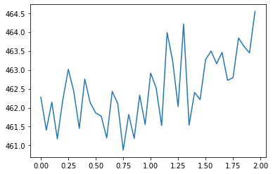

```
{0.0: 463.01372003437086, 0.05: 461.93601545288, 0.1: 461.3234350874295, 0.15000000000000002: 462.0828935127473, 0.2: 461.3762179765909, 0.25: 461.1371828667863, 0.30000000000000004: 460.3816295977028, 0.35000000000000003: 461.4517658721007, 0.4: 461.3465530245039, 0.45: 462.1496332182049, 0.5: 461.…
dict_values([463.01372003437086, 461.93601545288, 461.3234350874295, 462.0828935127473, 461.3762179765909, 461.1371828667863, 460.3816295977028, 461.4517658721007, 461.3465530245039, 462.1496332182049, 461.58337695766494, 462.29554927602607, 461.5992754181432, 462.05045331236056, 461.40714009358385,…
0.30000000000000004   460.3816295977028
```

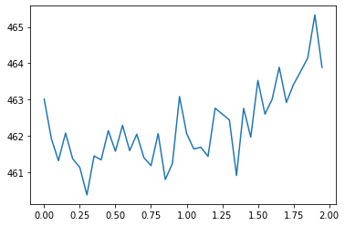

```
{0.0: 462.1704744594023, 0.05: 461.4029085445225, 0.1: 461.18768476014026, 0.15000000000000002: 462.51755769929446, 0.2: 462.4197072542104, 0.25: 460.503968851349, 0.30000000000000004: 461.2256661705202, 0.35000000000000003: 462.28439884261695, 0.4: 463.0017959334843, 0.45: 461.7958675241385, 0.5: 4…
dict_values([462.1704744594023, 461.4029085445225, 461.18768476014026, 462.51755769929446, 462.4197072542104, 460.503968851349, 461.2256661705202, 462.28439884261695, 463.0017959334843, 461.7958675241385, 461.2135495801117, 461.34593631547386, 462.15176156942965, 461.8376683659569, 462.4799722350831…
0.25   460.503968851349
```

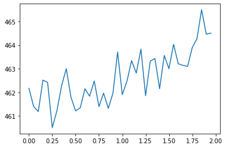

```
{0.0: 461.76068614668304, 0.05: 461.2550779768304, 0.1: 462.1273950269409, 0.15000000000000002: 461.3254700840828, 0.2: 461.0251776442169, 0.25: 461.3227139161806, 0.30000000000000004: 460.82992087172266, 0.35000000000000003: 461.4986394209458, 0.4: 461.48521748104713, 0.45: 461.44605894714664, 0.5:…
dict_values([461.76068614668304, 461.2550779768304, 462.1273950269409, 461.3254700840828, 461.0251776442169, 461.3227139161806, 460.82992087172266, 461.4986394209458, 461.48521748104713, 461.44605894714664, 462.0718104078198, 460.27290709640164, 462.74571586670334, 461.7419122958753, 462.24701492213…
0.55   460.27290709640164
```

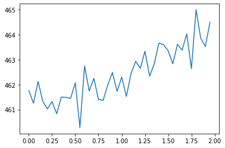

```
{0.0: 461.12118687600696, 0.05: 461.49135062120854, 0.1: 462.31313159922416, 0.15000000000000002: 462.04481664307036, 0.2: 461.2885637152491, 0.25: 461.25856618370176, 0.30000000000000004: 461.42229371040406, 0.35000000000000003: 463.1885661491023, 0.4: 461.5794370367658, 0.45: 460.84787013926626, 0…
dict_values([461.12118687600696, 461.49135062120854, 462.31313159922416, 462.04481664307036, 461.2885637152491, 461.25856618370176, 461.42229371040406, 463.1885661491023, 461.5794370367658, 460.84787013926626, 461.96254326580157, 462.25760860194123, 461.8276107164122, 462.3211200658264, 462.62175792…
0.45   460.84787013926626
```

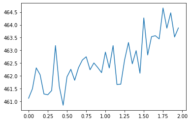

```
{0.0: 461.5878483663357, 0.05: 461.0511338634866, 0.1: 461.0305069892418, 0.15000000000000002: 462.0705582657327, 0.2: 462.1003432580714, 0.25: 460.4733921898789, 0.30000000000000004: 460.93637504260784, 0.35000000000000003: 461.8463325492091, 0.4: 461.2800257954975, 0.45: 461.5984736297234, 0.5: 46…
dict_values([461.5878483663357, 461.0511338634866, 461.0305069892418, 462.0705582657327, 462.1003432580714, 460.4733921898789, 460.93637504260784, 461.8463325492091, 461.2800257954975, 461.5984736297234, 461.54428218745625, 461.8419994129035, 462.21766027152523, 461.2082944961556, 461.12477232010383…
0.25   460.4733921898789
```

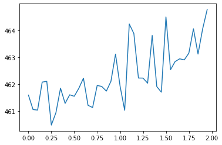

```
{0.2: 1, 0.55: 2, 0.6000000000000001: 1, 0.1: 1, 0.75: 1, 0.30000000000000004: 1, 0.25: 2, 0.45: 1}
```

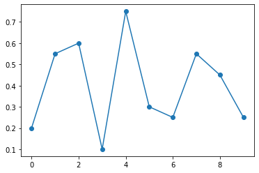

```
best_alpha =  0.55
```

```python
n_samples = 100
n_features = 1
noise = 20
X_full, t_full = datasets.make_regression(n_samples=n_samples, n_features=n_features, n_informative=1, noise=noise, random_state=37)
X_train, t_train, X_test, t_test = split_dataset(X_full, t_full)
X_real, t_real = datasets.make_regression(n_samples=n_samples, n_features=n_features, n_informative=1, noise=0., random_state=37)


model = RidgeRegression(alpha=0.24)
X_train_feat = extract_polynomial_features(X_train, 1)
X_test_feat = extract_polynomial_features(X_test, 1)
# print(X_train_feat)
model.fit(X_train_feat, t_train)

y_train = model.predict(X_train_feat, return_std=False)
y_test, y_test_std = model.predict(X_test_feat, return_std=True)
print("Mean Squared Error")
print("Train error:", mean_squared_error(y_train, t_train))
print("Test  error:", mean_squared_error(y_test, t_test))

print("Root Mean Squared Error")
print("Train error:", root_mean_squared_error(y_train, t_train))
print("Test  error:", root_mean_squared_error(y_test, t_test))

plt.scatter(X_train, t_train, facecolor="none", edgecolor="b", s=50, label="training data")
plt.plot(X_real, t_real, label="line")
plt.plot(X_test, y_test, label="prediction")
plt.fill_between(
    np.squeeze(X_test), y_test - y_test_std, y_test + y_test_std,
    color="orange", alpha=0.5, label="std.")
plt.legend()
plt.show()


(N, D) = X_full.shape

best_alpha = {}
chosen_alpha = []

for iter in range(10):
  alpha_errors = {}

  alpha_interval = np.arange(0, 2, 0.05)
  for alpha in alpha_interval:
    error_train = []
    error_test = []
    for j in range(100):
      X_subsamples = list()
      t_subsamples = list()

      indices = np.random.permutation(N)
      X_rand = X_full[indices]
      T_rand = t_full[indices]

      for i in range(0, 100, 10):
        X_subsamples.append(X_rand[i:i+10])
        t_subsamples.append(T_rand[i:i+10])

      k_test_errors = []
      for test in range(10):
        x_test_subsample = X_subsamples[test]
        t_test_subsample = t_subsamples[test]

        before = []
        after = []
        x_train_subsample = []
        t_train_subsample = []
        if test != 0 and test != 9:
          before = np.vstack(X_subsamples[:test])
          after = np.vstack(X_subsamples[test+1:])
          x_train_subsample = np.vstack((before, after))

          before = np.vstack(t_subsamples[:test])
          after = np.vstack(t_subsamples[test+1:])
          t_train_subsample = np.vstack((before, after))

          t_train_subsample = [elem for sublist in t_train_subsample for elem in sublist]
        else:
            if test == 0:
              after = np.vstack(X_subsamples[test+1:])
              x_train_subsample = np.vstack(after)

              after = np.vstack(t_subsamples[test+1:])
              t_train_subsample = np.vstack(after)

              t_train_subsample = [elem for sublist in t_train_subsample for elem in sublist]
            else:
              before = np.vstack(X_subsamples[:test])
              x_train_subsample = np.vstack(before)

              before = np.vstack(t_subsamples[:test])
              t_train_subsample = np.vstack(before)

              t_train_subsample = [elem for sublist in t_train_subsample for elem in sublist]

        model = RidgeRegression(alpha)
        X_train_feat = extract_polynomial_features(x_train_subsample, 1)
        X_test_feat = extract_polynomial_features(x_test_subsample, 1)

        model.fit(X_train_feat, t_train_subsample)

        y_train = model.predict(X_train_feat, return_std=False)
        y_test, y_test_std = model.predict(X_test_feat, return_std=True)
        error_train.append(mean_squared_error(y_train, t_train_subsample))
        error_test.append(mean_squared_error(y_test, t_test_subsample))
        k_test_errors.append(mean_squared_error(y_test, t_test_subsample))
        # print(test," ",mean_squared_error(y_test, t_test_subsample))
        # print("Mean Squared Error")
        # print("Train error:", mean_squared_error(y_train, t_train_subsample))
        # print("Test  error:", mean_squared_error(y_test, t_test_subsample))

        # print("Root Mean Squared Error")
        # print("Train error:", root_mean_squared_error(y_train, t_train_subsample))
        # print("Test  error:", root_mean_squared_error(y_test, t_test_subsample))

        # plt.scatter(X_train, t_train, facecolor="none", edgecolor="b", s=50, label="training data")
        # plt.plot(X_real, t_real, label="line")
        # plt.plot(x_test_subsample, y_test, label="prediction")
        # plt.fill_between(
        #     np.squeeze(x_test_subsample), y_test - y_test_std, y_test + y_test_std,
        #     color="orange", alpha=0.5, label="std.")
        # plt.legend()
        # plt.show()
      # print(sum(k_test_errors)/10)

    # print("Alpha = ", alpha)
    # print("Train error:", sum(error_train)/len(error_train))
    # print("Test error:", sum(error_test)/len(error_test))
    # plot_x = [i for i in range(1000)]
    # print(len(error_test))
    # plt.scatter(plot_x, error_test, facecolor="none", edgecolor="b", s=50, label="test")
    # plt.show()
    alpha_errors[alpha] = sum(error_test)/len(error_test)

  print(alpha_errors)
  print(alpha_errors.values())
  key = min(alpha_errors,key=alpha_errors.get)
  value = alpha_errors[min(alpha_errors,key=alpha_errors.get)]
  print(key, " ", value)
  chosen_alpha.append(key)
  plt.plot(alpha_interval, list(alpha_errors.values()))
  plt.show()

  if best_alpha.get(key) is not None:
    best_alpha[key] = best_alpha.get(key) + 1
  else:
    best_alpha[key] = 1

best_alpha_key = max(best_alpha,key=best_alpha.get)
print(best_alpha)


plt.plot([i for i in range(10)], chosen_alpha, '-o')
plt.show()

print("best_alpha = ", best_alpha_key)
```

Am ales intervalul (0, 2), deoarece am observat ca graficul erorilor in functie de alpha este ascendent. Cu cat alpha este mai mare, cu atat eroarea este mai ridicata.

# Problema 3

```python
import pandas as pd
import csv
from sklearn.model_selection import train_test_split


class Node():
    """ Representation for a node from the regression tree """
    def __init__(self, X, Y, attributes, min_attribute=None, split_point=None, node_type=None, depth=0, no_examples=5):

        self.X = X
        self.Y = Y
        self.no_examples = no_examples
        self.depth = depth
        self.left = None
        self.right = None
        self.attributes = attributes
        self.rmse = self.root_mean_squared_error(self.Y, np.mean(self.Y))
        self.rss = self.mean_squared_error(self.Y, np.mean(Y))
        self.min_attribute = min_attribute
        self.split_point = split_point
        self.node_type = node_type


    def mean_squared_error(self, y, t):
      return np.mean((y - t) * (y- t))

    def root_mean_squared_error(self, y, t):
      return math.sqrt(np.mean((t - y) * (t - y)))

    def get_split_points(self, X):
      split_points = []
      for i in range(0, len(X) - 1):
        split_points.append((X[i] + X[i+1])/2)
      return split_points

    def get_min_rss_attribute(self):
      currX = self.X.copy()
      min_rss_attribute = [self.rss, "" , None]

      for attribute in self.attributes:
        if attribute != "mpg":
          X_attribute = currX.dropna().sort_values(attribute)
          split_points = self.get_split_points(X_attribute[attribute].unique())
          for split_point in split_points:
            lower_points = X_attribute[X_attribute[attribute] < split_point]['mpg'].values
            greater_points = X_attribute[X_attribute[attribute] > split_point]['mpg'].values
            rss_lower = lower_points - np.mean(lower_points)
            rss_greater = greater_points - np.mean(greater_points)
            # print(np.sum(np.square(rss_lower)) + np.sum(np.square(rss_greater)))
            X_con = np.concatenate((rss_lower, rss_greater))
            rss = np.mean(X_con*X_con)
            # print("RSS ", rss)
            if min_rss_attribute[0] > rss:
              min_rss_attribute[0] = rss
              min_rss_attribute[1] = attribute
              min_rss_attribute[2] = split_point

      return min_rss_attribute

    def build_tree(self):
      currX = self.X.copy()
      if len(self.Y) >= self.no_examples:
        min_rss_attribute = self.get_min_rss_attribute()
        attribute = min_rss_attribute[1]
        split_point = min_rss_attribute[2]
        self.min_attribute = attribute
        if attribute != "":
          lower_points = currX[currX[attribute] <= split_point].copy()
          greater_points = currX[currX[attribute] > split_point].copy()
          lower = Node(lower_points[self.attributes], list(lower_points['mpg']), self.attributes, attribute, split_point, "left", self.depth + 1)
          self.left = lower
          self.left.build_tree()
          greater =  Node(greater_points[self.attributes], list(greater_points['mpg'].values), self.attributes, attribute, split_point, "right", self.depth + 1)
          self.right  = greater
          self.right.build_tree()

    def display(self):
      # print('\t'*self.depth, self.min_attribute)
      if self.node_type == "left":
        print('\t'*self.depth, self.min_attribute," <= ", self.split_point)
      else:
        if self.node_type == "right":
          print('\t'*self.depth, self.min_attribute," > ", self.split_point)
        else:
          print("root")
      print('\t'*self.depth, "RSS = ", self.rss)
      print('\t'*self.depth,"EXAMPLES = ", len(self.Y))
      print('\t'*self.depth,"Prediction = ", np.mean(self.Y))
      if self.left is not None:
          self.left.display()

      if self.right is not None:
          self.right.display()

    def get_number_of_leaves(self, root):
      if root is None:
        return 0
      if root.left is None and root.right is None:
        return 1
      return root.get_number_of_leaves(root.right) + root.get_number_of_leaves(root.left)




attributes_dict = {
    "mpg":[],
    "cylinders":[],
    "displacement":[],
    "horsepower":[],
    "weight":[],
    "acceleration":[],
    "model_year":[],
    "origin":[],
    "car_name":[]
    }

f_in = open('auto-mpg.data', "r")
csv_reader = csv.reader(f_in, delimiter="\t");
for row in csv_reader:
  attributes_values, car_name = row
  if "?" not in attributes_values:
    float_attributes_values = [float(x) for x in attributes_values.split()]
    attributes_dict["mpg"].append(float_attributes_values[0])
    attributes_dict["cylinders"].append(float_attributes_values[1])
    attributes_dict["displacement"].append(float_attributes_values[2])
    attributes_dict["horsepower"].append(float_attributes_values[3])
    attributes_dict["weight"].append(float_attributes_values[4])
    attributes_dict["acceleration"].append(float_attributes_values[5])
    attributes_dict["model_year"].append(float_attributes_values[6])
    attributes_dict["origin"].append(float_attributes_values[7])
    attributes_dict["car_name"].append(car_name)

f_in.close()


data = pd.DataFrame.from_dict(attributes_dict)
attributes = [
    "mpg",
    "cylinders",
    "displacement",
    "horsepower",
    "weight",
    "acceleration",
    "model_year",
    "origin"]

X = data[attributes]
X_train, X_test = train_test_split(X, test_size=0.2, shuffle = False)
Y_train = list(X_train['mpg'].values)
Y_test = list(X_test['mpg'].values)

root = Node(X_train, Y_train, attributes, node_type="root")
root.build_tree()
root.display()
# print(np.sum(np.square(Y_train - np.mean(Y_train))))
# print(root.get_number_of_leaves(root))
# print(root.get_min_rss_attribute())
```

```
root
 RSS =  44.73978809623452
 EXAMPLES =  313
 Prediction =  21.3297124600639
	 weight  <=  2764.5
	 RSS =  23.90274563820019
	 EXAMPLES =  132
	 Prediction =  27.524242424242424
		 model_year  <=  2219.5
		 RSS =  18.976161616161615
		 EXAMPLES =  66
		 Prediction =  30.733333333333334
			 weight  <=  76.5
			 RSS =  9.817174515235457
			 EXAMPLES =  38
			 Prediction =  28.342105263157894
				 origin  <=  2087.0
				 RSS =  6.180268595041323
				 EXAMPLES =  22
				 Prediction =  29.886363636363637
					 weight  <=  2.5
					 RSS =  3.0236686390532546
					 EXAMPLES =  13
					 Prediction =  28.26923076923077
						 acceleration  <=  1981.5
						 RSS =  2.2222222222222223
						 EXAMPLES =  9
						 Prediction =  27.5
							 acceleration  <=  14.85
							 RSS =  0.05555555555555556
							 EXAMPLES =  3
							 Prediction =  29.166666666666668
							 displacement  >  14.85
							 RSS =  1.2222222222222223
							 EXAMPLES =  6
							 Prediction =  26.666666666666668
								 displacement  <=  73.5
								 RSS =  0.0
								 EXAMPLES =  1
								 Prediction =  29.0
```

[output cut: 965 more lines]

```
						 RSS =  0.06
						 EXAMPLES =  5
						 Prediction =  15.7
							 displacement  <=  350.5
							 RSS =  0.0
							 EXAMPLES =  2
							 Prediction =  15.5
							 displacement  >  350.5
							 RSS =  0.05555555555555556
							 EXAMPLES =  3
							 Prediction =  15.833333333333334
					 model_year  >  77.5
					 RSS =  0.5299999999999998
					 EXAMPLES =  4
					 Prediction =  16.6
```

```python
import pandas as pd
import csv
from sklearn.model_selection import train_test_split


class Node():
    """ Representation for a node from the regression tree """
    def __init__(self, X, Y, attributes, min_attribute=None, split_point=None, node_type=None, depth=0, no_examples=5):

        self.X = X
        self.Y = Y
        self.no_examples = no_examples
        self.depth = depth
        self.left = None
        self.right = None
        self.attributes = attributes
        self.rmse = self.root_mean_squared_error(self.Y, np.mean(self.Y))
        self.rss = np.sum(np.square(self.Y - np.mean(Y)))
        self.min_attribute = min_attribute
        self.split_point = split_point
        self.node_type = node_type
        self.parrent_attribute = None
        self.min_g = -1


    def mean_squared_error(self, y, t):
      return np.mean((y - t) * (y- t))

    def root_mean_squared_error(self, y, t):
      return math.sqrt(np.mean((t - y) * (t - y)))

    def get_split_points(self, X):
      split_points = []
      for i in range(0, len(X) - 1):
        split_points.append((X[i] + X[i+1])/2)
      return split_points

    def get_min_rss_attribute(self):
      currX = self.X.copy()
      min_rss_attribute = [self.rss, "" , None]

      for attribute in self.attributes:
        if attribute != "mpg":
          X_attribute = currX.dropna().sort_values(attribute)
          split_points = self.get_split_points(X_attribute[attribute].unique())
          for split_point in split_points:
            lower_points = X_attribute[X_attribute[attribute] < split_point]['mpg'].values
            greater_points = X_attribute[X_attribute[attribute] > split_point]['mpg'].values
            rss_lower = lower_points - np.mean(lower_points)
            rss_greater = greater_points - np.mean(greater_points)
            rss = np.sum(np.square(rss_lower)) + np.sum(np.square(rss_greater))
            if min_rss_attribute[0] > rss:
              min_rss_attribute[0] = rss
              min_rss_attribute[1] = attribute
              min_rss_attribute[2] = split_point

      return min_rss_attribute

    def build_tree(self):
      currX = self.X.copy()
      if len(self.Y) >= self.no_examples and self.rss != 0:
        min_rss_attribute = self.get_min_rss_attribute()
        attribute = min_rss_attribute[1]
        split_point = min_rss_attribute[2]
        self.min_attribute = attribute
        if attribute != "":
          lower_points = currX[currX[attribute] <= split_point].copy()
          greater_points = currX[currX[attribute] > split_point].copy()
          lower = Node(lower_points[self.attributes], list(lower_points['mpg']), self.attributes, split_point=split_point, node_type="left", depth=self.depth + 1)
          lower.parrent_attribute = attribute
          self.left = lower
          self.left.build_tree()
          greater =  Node(greater_points[self.attributes], list(greater_points['mpg'].values), self.attributes, split_point=split_point,node_type="right", depth=self.depth + 1)
          greater.parrent_attribute = attribute
          self.right  = greater
          self.right.build_tree()

    def display(self):
      if self.node_type == "left":
        print('\t'*self.depth, self.parrent_attribute," <= ", self.split_point)
      else:
        if self.node_type == "right":
          print('\t'*self.depth, self.parrent_attribute," > ", self.split_point)
        else:
          print("ROOT")

      if self.node_type == "root":
        print("RSS = ", self.rss)
        print("EXAMPLES = ", len(self.Y))
        print("Prediction = ", np.mean(self.Y))
        print("MIN RSS Attribute", self.min_attribute)
      else:
        print('\t'*self.depth, "RSS = ", self.rss)
        print('\t'*self.depth,"EXAMPLES = ", len(self.Y))
        print('\t'*self.depth,"Prediction = ", np.mean(self.Y))
        print('\t'*self.depth,"MIN RSS Attribute", self.min_attribute)

      if self.left is not None:
          self.left.display()

      if self.right is not None:
          self.right.display()

    def get_number_of_leaves(self, root):
      if root is None:
        return 0
      if root.left is None and root.right is None:
        return 1
      return root.get_number_of_leaves(root.right) + root.get_number_of_leaves(root.left)

    def get_sum_RSS_of_leaves(self, root):
      if root is None:
        return 0
      if root.left is None and root.right is None:
        return root.rss
      return root.get_sum_RSS_of_leaves(root.right) + root.get_sum_RSS_of_leaves(root.left)

    def get_best_g_value(self, root, curr_node):
      if curr_node is not None:
        if curr_node.left is not None and curr_node.right is not None:
          no_leaves = root.get_number_of_leaves(curr_node)
          if no_leaves != 1:
            R_T_t = root.get_sum_RSS_of_leaves(curr_node)
            g_t = (curr_node.rss - R_T_t)/(no_leaves - 1)
          if g_t < root.min_g:
            root.min_g = g_t

      if curr_node.left is not None:
          curr_node.get_best_g_value(root, curr_node.left)

      if curr_node.right is not None:
          curr_node.get_best_g_value(root, curr_node.right)

    def cut_tree(self, root, min_g):
        if root is not None:
            if root.left is not None and root.right is not None:
                no_leaves = root.get_number_of_leaves(root)
                if no_leaves != 1:
                  R_T_t = root.get_sum_RSS_of_leaves(root)
                  g_t = (root.rss - R_T_t)/(no_leaves - 1)
                  if g_t == min_g:
                    root.left = None
                    root.right = None

        if root.left is not None:
          root.cut_tree(root.left, min_g)

        if root.right is not None:
          root.cut_tree(root.right, min_g)

    def get_regression_trees(self, root):
      trees = []
      alphas = []
      trees.append(root)
      alphas.append(0)
      no_leaves = root.get_number_of_leaves(root)
      while no_leaves > 2:
        R_T_t = root.get_sum_RSS_of_leaves(root)
        min_g_t = (root.rss - R_T_t)/(no_leaves - 1)
        root.min_g = min_g_t
        root.get_best_g_value(root, root)
        root.cut_tree(root, root.min_g)
        alphas.append(root.min_g)
        trees.append(root)
        no_leaves = root.get_number_of_leaves(root)
      return trees, alphas



attributes_dict = {
    "mpg":[],
    "cylinders":[],
    "displacement":[],
    "horsepower":[],
    "weight":[],
    "acceleration":[],
    "model_year":[],
    "origin":[],
    "car_name":[]
    }

f_in = open('auto-mpg.data', "r")
csv_reader = csv.reader(f_in, delimiter="\t");
for row in csv_reader:
  attributes_values, car_name = row
  if "?" not in attributes_values:
    float_attributes_values = [float(x) for x in attributes_values.split()]
    attributes_dict["mpg"].append(float_attributes_values[0])
    attributes_dict["cylinders"].append(float_attributes_values[1])
    attributes_dict["displacement"].append(float_attributes_values[2])
    attributes_dict["horsepower"].append(float_attributes_values[3])
    attributes_dict["weight"].append(float_attributes_values[4])
    attributes_dict["acceleration"].append(float_attributes_values[5])
    attributes_dict["model_year"].append(float_attributes_values[6])
    attributes_dict["origin"].append(float_attributes_values[7])
    attributes_dict["car_name"].append(car_name)

f_in.close()


data = pd.DataFrame.from_dict(attributes_dict)
attributes = [
    "mpg",
    "cylinders",
    "displacement",
    "horsepower",
    "weight",
    "acceleration",
    "model_year",
    "origin"]

X = data[attributes]
X_train, X_test = train_test_split(X, test_size=0.2, shuffle = False)
Y_train = list(X_train['mpg'].values)
Y_test = list(X_test['mpg'].values)

root = Node(X_train, Y_train, attributes, node_type="root")
root.build_tree()

root.display()

no_leaves = root.get_number_of_leaves(root)
R_T_t = root.get_sum_RSS_of_leaves(root)
min_g_t = (root.rss - R_T_t)/(no_leaves - 1)
root.min_g = min_g_t

trees, alphas = root.get_regression_trees(root)

print(alphas)
trees[-1].display()
```

```
ROOT
RSS =  14003.553674121405
EXAMPLES =  313
Prediction =  21.3297124600639
MIN RSS Attribute weight
	 weight  <=  2764.5
	 RSS =  3155.162424242425
	 EXAMPLES =  132
	 Prediction =  27.524242424242424
	 MIN RSS Attribute weight
		 weight  <=  2219.5
		 RSS =  1252.4266666666665
		 EXAMPLES =  66
		 Prediction =  30.733333333333334
		 MIN RSS Attribute model_year
			 model_year  <=  76.5
			 RSS =  373.0526315789474
			 EXAMPLES =  38
			 Prediction =  28.342105263157894
			 MIN RSS Attribute weight
				 weight  <=  2087.0
				 RSS =  135.9659090909091
				 EXAMPLES =  22
				 Prediction =  29.886363636363637
				 MIN RSS Attribute origin
					 origin  <=  2.5
					 RSS =  39.30769230769231
					 EXAMPLES =  13
					 Prediction =  28.26923076923077
					 MIN RSS Attribute weight
						 weight  <=  1981.5
						 RSS =  20.0
						 EXAMPLES =  9
						 Prediction =  27.5
						 MIN RSS Attribute model_year
							 model_year  <=  74.5
							 RSS =  7.333333333333334
							 EXAMPLES =  6
							 Prediction =  26.666666666666668
							 MIN RSS Attribute displacement
```

[output cut: 1236 more lines]

```
ROOT
RSS =  14003.553674121405
EXAMPLES =  313
Prediction =  21.3297124600639
MIN RSS Attribute weight
	 weight  <=  2764.5
	 RSS =  3155.162424242425
	 EXAMPLES =  132
	 Prediction =  27.524242424242424
	 MIN RSS Attribute weight
	 weight  >  2764.5
	 RSS =  2089.353259668508
	 EXAMPLES =  181
	 Prediction =  16.8121546961326
	 MIN RSS Attribute horsepower
```